# R Notebook

# geoR solution

Paulo Justiniano Ribeiro Jr Geostatistical analysis with the geoR package Paulo Justiniano Ribeiro Jr, LEG: Statistics and Geoinformation Lab, DEST: Department of Statistics, UFPR: Federal University of Paraná

Table of contents

- A (very) basic geoR session
- Loading and exploring the data -Model estimation
- Model prediction
- Bayesian inferance
- This is a brief overview of some functionalities in geoR. We refer to the geoR “Tutorials” page http://www.leg.ufpr.br/geoR/tutorials for further examples.

## A (very) basic geoR session

```r
## Required package.
require(geoR)
## Loading a data-set included in the package
data(s100)
```

We first do a quick data display with exploratory checks on spatial patterns, trends in the coordinates, and distribution of the data. We are using the default plot for a geodata object in geoR: plot.geodata. The lowess argument adds a smooth line to the upper right scatter plot (data value vs y value) and to the lower left scatter plot (x value vs data value). The upper left plot shows color coded data quartile at the location of the data

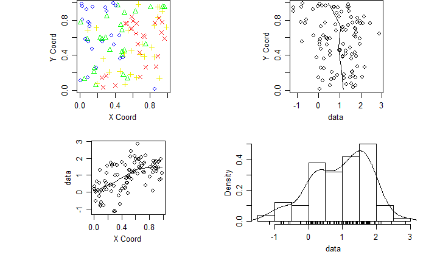

```r
plot(s100, lowess = TRUE)
```

Another function allows for more options for displaying the data.

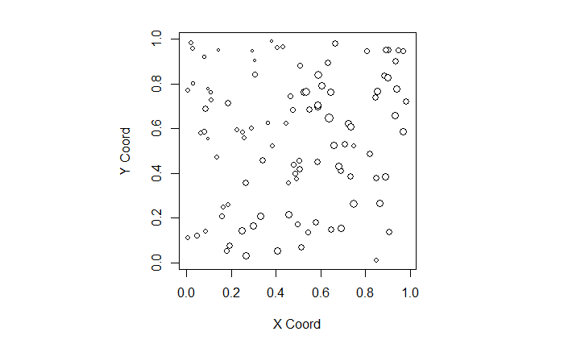

```r
points(s100)
```

```r
args(points.geodata)
```

```
function (x, coords = x$coords, data = x$data, data.col = 1,
    borders = x$borders, pt.divide = c("data.proportional", "rank.proportional",
        "quintiles", "quartiles", "deciles", "equal"), lambda = 1,
    trend = "cte", abs.residuals = FALSE, weights.divide = "units.m",
    cex.min, cex.max, cex.var, pch.seq, col.seq, add.to.plot = FALSE,
    x.leg, y.leg = NULL, dig.leg = 2, round.quantiles = FALSE,
    permute = FALSE, ...)
NULL
```

The brief summary include information on the distances between data points.

```r
summary(s100)
```

```
Number of data points: 100

Coordinates summary
        Coord.X    Coord.Y
min 0.005638006 0.01091027
max 0.983920544 0.99124979

Distance summary
        min         max
0.007640962 1.278175109

Data summary
      Min.    1st Qu.     Median       Mean    3rd Qu.       Max.
-1.1676955  0.2729882  1.1045936  0.9307179  1.6101707  2.8678969

Other elements in the geodata object
[1] "cov.model" "nugget"    "cov.pars"  "kappa"     "lambda"
```

There are several options for computing the empirical variogram. Here we use default options except for the argument setting the maximum distance (max.dist) to be considered between pairs of points.

```r
s100.v <- variog(s100, max.dist = 1)
```

```
variog: computing omnidirectional variogram
```

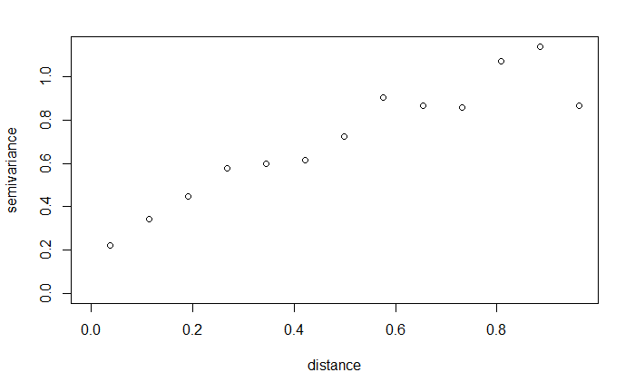

```r
plot(s100.v)
```

Turning to the parameter estimation we fit the model with a constant mean, isotropic exponential correlation function and allowing for estimating the variance of the conditionally independent observations (nugget variance)

```r
(s100.ml <- likfit(s100, ini = c(1, 0.15)))
```

```
---------------------------------------------------------------
likfit: likelihood maximisation using the function optim.
likfit: Use control() to pass additional
         arguments for the maximisation function.
        For further details see documentation for optim.
likfit: It is highly advisable to run this function several
        times with different initial values for the parameters.
likfit: WARNING: This step can be time demanding!
---------------------------------------------------------------
likfit: end of numerical maximisation.
likfit: estimated model parameters:
    beta    tausq  sigmasq      phi
"0.7766" "0.0000" "0.7517" "0.1827"
Practical Range with cor=0.05 for asymptotic range: 0.5473814

likfit: maximised log-likelihood = -83.57
```

```r
summary(s100.ml)
```

```
Summary of the parameter estimation
-----------------------------------
Estimation method: maximum likelihood

Parameters of the mean component (trend):
  beta
0.7766

Parameters of the spatial component:
   correlation function: exponential
      (estimated) variance parameter sigmasq (partial sill) =  0.7517
      (estimated) cor. fct. parameter phi (range parameter)  =  0.1827
   anisotropy parameters:
      (fixed) anisotropy angle = 0  ( 0 degrees )
      (fixed) anisotropy ratio = 1

Parameter of the error component:
      (estimated) nugget =  0

Transformation parameter:
      (fixed) Box-Cox parameter = 1 (no transformation)

Practical Range with cor=0.05 for asymptotic range: 0.5473814

Maximised Likelihood:
   log.L n.params      AIC      BIC
"-83.57"      "4"  "175.1"  "185.6"

non spatial model:
   log.L n.params      AIC      BIC
"-125.8"      "2"  "255.6"  "260.8"

Call:
likfit(geodata = s100, ini.cov.pars = c(1, 0.15))
```

Finally, we start the spatial prediction defining a grid of points. The kriging function by default performs ordinary kriging. It minimaly requires the data, prediction locations and estimated model parameters.

```r
s100.gr <- expand.grid((0:100)/100, (0:100)/100)
s100.kc <- krige.conv(s100, locations = s100.gr, krige = krige.control(obj.model = s100.ml))
```

```
krige.conv: model with constant mean
krige.conv: Kriging performed using global neighbourhood
```

```r
names(s100.kc)
```

```
[1] "predict"      "krige.var"    "beta.est"     "distribution" "message"
[6] "call"
```

If the locations forms a grid the predictions can be visualised as image, contour or persp plots. Image plots shows the predicted values (left) and the respective std errors.

```r
par(mfrow = c(1, 2), mar = c(3.5, 3.5, 0.5, 0.5))
image(s100.kc, col = gray(seq(1, 0.2, l = 21)))
contour(s100.kc, nlevels = 11, add = TRUE)
```

[figure not shown]

```r
image(s100.kc, val = sqrt(krige.var), col = gray(seq(1, 0.2, l = 21)))
```

It is worth to notice that under the Gaussian model the prediction errors depend on the coordinates of the data, and not on their values (except through model parameter estimates).

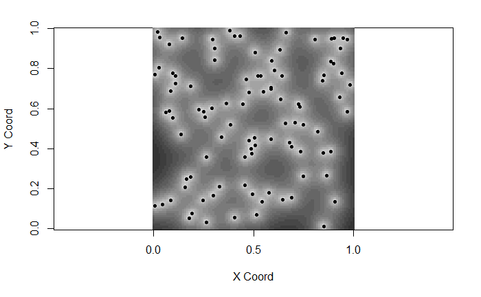

```r
image(s100.kc, val = sqrt(krige.var), col = gray(seq(1, 0.2, l = 21)), coords.data = TRUE)
```

## Loading and exploring the data

There are some datasets included in geoR which can be listed as follows. We use some of them to illustrate further options in the functions.

### Datasets included in geoR.

```r
#data(package = "geoR")
```

Some of them are of the class “geodata” which is convenient (but not compulsory!) to use with geoR functions. Others are simply data.frames from which “geodata” can be created. “geodata” (S3) objects are just lists with a class “geodata” and must have elements “coords” and “data”. Optional elements includes “covariates”, “units.m” among others (see help(as.geodata)).

```r
class(s100)
```

```
[1] "geodata"
```

```r
class(parana)
```

```
[1] "geodata"
```

```r
class(Ksat)
```

```
[1] "geodata"
```

```r
class(camg)
```

```
[1] "data.frame"
```

```r
head(camg)
```

|  | east | north | elevation | region | ca020 | mg020 | ctc020 | ca2040 | mg2040 | ctc2040 |
| --- | --- | --- | --- | --- | --- | --- | --- | --- | --- | --- |
| 1 | 5710 | 4829 | 6.10 | 3 | 52 | 18 | 106.0 | 40 | 16 | 86.3 |
| 2 | 5727 | 4875 | 6.05 | 3 | 57 | 20 | 131.1 | 49 | 21 | 123.1 |
| 3 | 5745 | 4922 | 6.30 | 3 | 72 | 22 | 114.6 | 63 | 22 | 101.7 |
| 4 | 5764 | 4969 | 6.60 | 3 | 74 | 11 | 114.4 | 74 | 12 | 95.6 |
| 5 | 5781 | 5015 | 6.60 | 3 | 68 | 34 | 124.4 | 44 | 36 | 106.3 |
| 6 | 5799 | 5062 | 5.75 | 3 | 45 | 27 | 132.9 | 27 | 22 | 105.3 |

```r
ctc020 <- as.geodata(camg, coords.col = c(1, 2), data.col = 7, covar.col = c(3, 4))
summary(ctc020)
```

```
Number of data points: 178

Coordinates summary
    east north
min 4957  4829
max 5961  5720

Distance summary
       min        max
  43.01163 1138.11774

Data summary
    Min.  1st Qu.   Median     Mean  3rd Qu.     Max.
 72.0000 122.2000 132.2500 132.1854 141.0750 186.2000

Covariates summary
   elevation     region
 Min.   :3.300   1: 14
 1st Qu.:5.200   2: 48
 Median :5.650   3:116
 Mean   :5.524
 3rd Qu.:6.000
 Max.   :6.600
```

The function calls shown above mostly use default options and it is worth examine the arguments (and the help files).

```r
args(plot.geodata)
```

```
function (x, coords = x$coords, data = x$data, borders = x$borders,
    trend = "cte", lambda = 1, col.data = 1, weights.divide = "units.m",
    lowess = FALSE, scatter3d = FALSE, density = TRUE, rug = TRUE,
    qt.col, ...)
NULL
```

```r
args(points.geodata)
```

```
function (x, coords = x$coords, data = x$data, data.col = 1,
    borders = x$borders, pt.divide = c("data.proportional", "rank.proportional",
        "quintiles", "quartiles", "deciles", "equal"), lambda = 1,
    trend = "cte", abs.residuals = FALSE, weights.divide = "units.m",
    cex.min, cex.max, cex.var, pch.seq, col.seq, add.to.plot = FALSE,
    x.leg, y.leg = NULL, dig.leg = 2, round.quantiles = FALSE,
    permute = FALSE, ...)
NULL
```

```r
args(variog)
```

```
function (geodata, coords = geodata$coords, data = geodata$data,
    uvec = "default", breaks = "default", trend = "cte", lambda = 1,
    option = c("bin", "cloud", "smooth"), estimator.type = c("classical",
        "modulus"), nugget.tolerance, max.dist, pairs.min = 2,
    bin.cloud = FALSE, direction = "omnidirectional", tolerance = pi/8,
    unit.angle = c("radians", "degrees"), angles = FALSE, messages,
    ...)
NULL
```

We point in particular to three arguments:

- borders: a matrix with coordinates of a polygon limiting the area
- lambda: parameter of the BoxCox transformation
- trend: a matrix, formula or special words (“1st”, “2nd”) specifying a mean model. To find out more about the trend argument, look at trend.spatial.

Borders are conveniently dealt with if included in the geodata object. As an example, let us add borders to the s100 data.

```r
s100$borders <- matrix(c(0,0,1,0,1,1,0,1,0,0), ncol=2, byrow=TRUE)
points(s100)
```

If you don’t have the coordinates of the border consider setting them manually by using “locator()” over the “points()” plot.

The dataset Ksat with data on the saturated soil conductivity has a clear asymetric behaviour and the BoxCox transformation suggests to log transform the data.

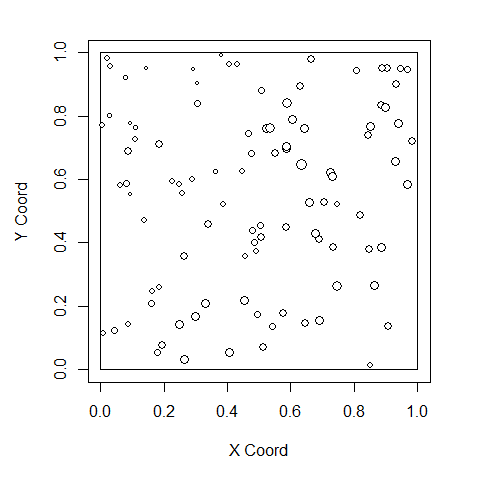

```r
s100$borders <- matrix(c(0,0,1,0,1,1,0,1,0,0), ncol=2, byrow=TRUE)
points(s100)
```

The differences between the exploratory plots are clear.

```r
data(Ksat)
require(MASS)
summary(Ksat)
```

```
Number of data points: 32

Coordinates summary
       x   y
min  2.5 0.8
max 21.0 9.1

Distance summary
      min       max
 0.509902 18.552897

Borders summary
       x  y
min  0.0  0
max 22.5 13

Data summary
     Min.   1st Qu.    Median      Mean   3rd Qu.      Max.
0.0200000 0.0922500 0.3050000 0.8720625 1.1425000 4.3000000
```

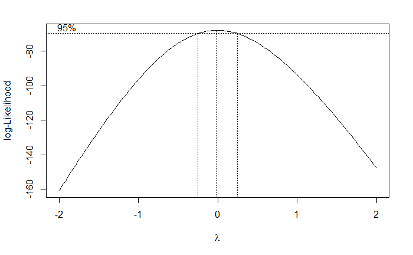

```r
boxcox(Ksat)
```

We now use the Paraná rainfall data to illustrate the usage and effect of trend argument. Notice that the data also include the borders of the state. It may be helpful to also have a topographic map of the state.

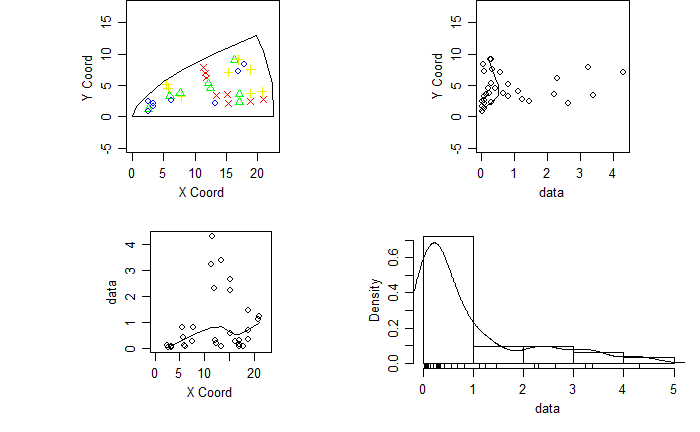

```r
plot(Ksat, lowess = TRUE)
```

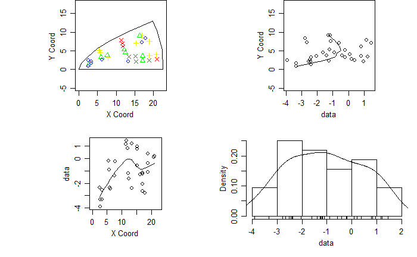

```r
plot(Ksat, lowess = TRUE, lambda = 0)
```

It is clear from the exploratory plot that there is a gradient of the response along the E-W and N-S coordinates.

```r
data(parana)
summary(parana)
```

```
Number of data points: 143

Coordinates summary
        east    north
min 150.1220  70.3600
max 768.5087 461.9681

Distance summary
     min      max
  1.0000 619.4925

Borders summary
        east    north
min 137.9873  46.7695
max 798.6256 507.9295

Data summary
    Min.  1st Qu.   Median     Mean  3rd Qu.     Max.
162.7700 234.1900 269.9200 274.4106 318.2300 413.7000

Other elements in the geodata object
[1] "loci.paper"
```

If the argument trend is provided an ordinary regression is fitted and the residuals are plotted. The options trend=“1st” defines a linear trend in the coordinates and is equivalent to trend=~coords. More generally a formula on a set of covariates can be used.

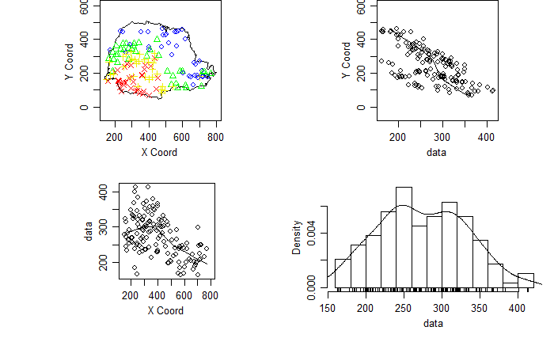

```r
plot(parana, lowess = TRUE)
```

The effect of the trend on the variogram is very noticeable in this example.

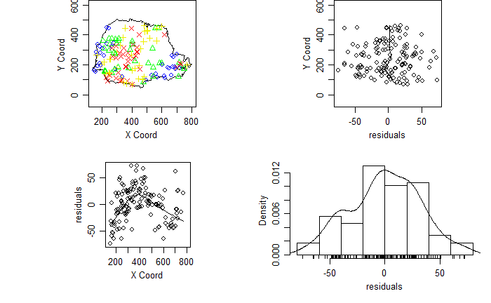

```r
plot(parana, trend = "1st", lowess = TRUE)
```

Next we show a simple Monte Carlo test using the empirical variogram. The envelope reflects the assumption of no spatial correlation and is given by permutations of the data across the sampling locations.

```r
par(mfrow = c(1, 2))
parana.vario <- variog(parana, max.dist = 400)
```

```
variog: computing omnidirectional variogram
```

```r
plot(parana.vario)
parana.variot <- variog(parana, trend = "1st", max.dist = 400)
```

```
variog: computing omnidirectional variogram
```

[figure not shown]

```r
plot(parana.variot)
```

To close this section we show a helper function which facilitate building empirical variograms on different directions which may be used to investigate anisotropy. The default directions are 0, 45, 90 and 135 degrees. So to compute the 0 direction variogram, you go through each point and consider only its square distances to points that are between -22.5 and 22.5 degrees from the point considered. Repeat for all points and average.

```r
s100.v <- variog(s100, max.dist = 1)
```

```
variog: computing omnidirectional variogram
```

```r
s100.v.env <- variog.mc.env(s100, obj.variog = s100.v)
```

```
variog.env: generating 99 simulations by permutating data values
variog.env: computing the empirical variogram for the 99 simulations
variog.env: computing the envelops
```

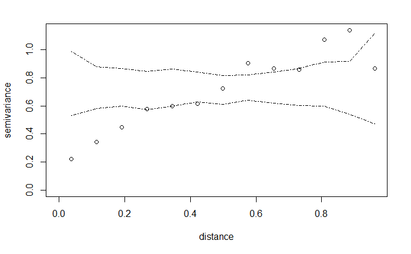

```r
plot(s100.v, env = s100.v.env)
```

### Question 1:

Investigate the residual spatial structure for the Paraná rainfall data. Is the linear trend sufficient, or do you need a more complicated structure to explain the spatial dependence?

#### Model estimation

The are four methods for estimating the (covariance) model parameters implemented in geoR.

- visual variogram fitting: using the function eyefit().
- variogram fitting: using the function variofit() basically fitting a non-linear model to the empirical variogram.
- likelihood (ML or REML): using the function likfit().
- Bayesian inference: using the function krige.bayes().

##### eyefit()

```r
s100.v4 <- variog4(s100, max.dist = 1)
```

```
variog: computing variogram for direction = 0 degrees (0 radians)
        tolerance angle = 22.5 degrees (0.393 radians)
variog: computing variogram for direction = 45 degrees (0.785 radians)
        tolerance angle = 22.5 degrees (0.393 radians)
variog: computing variogram for direction = 90 degrees (1.571 radians)
        tolerance angle = 22.5 degrees (0.393 radians)
variog: computing variogram for direction = 135 degrees (2.356 radians)
        tolerance angle = 22.5 degrees (0.393 radians)
variog: computing omnidirectional variogram
```

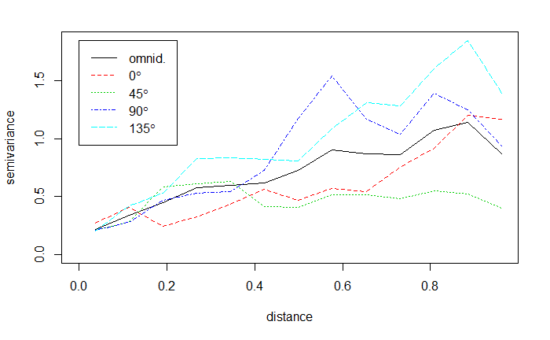

```r
plot(s100.v4, env = s100.v.env, omni = TRUE)
```

##### variofit()

variofit() allows for several options. In what follows we show least squares based variogram fits for the parana data under constant mean and a trend in the coordinates. By default a exponential correlation function (which corresponds to the Matérn model with kappa=0.5) is used. We also show fits for spherical and Matérn (with kappa=1.5) variogram models.

```r
parana.vfit.exp <- variofit(parana.vario)
parana.vfit.mat1.5 <- variofit(parana.vario, kappa=1.5)
parana.vfit.sph <- variofit(parana.vario, cov.model="sph")
parana.vtfit.exp <- variofit(parana.variot)
parana.vtfit.mat1.5 <- variofit(parana.variot,kappa=1.5)
parana.vtfit.sph <- variofit(parana.variot, cov.model="sph")

par(mfrow=c(1,2))
plot(parana.vario)
lines(parana.vfit.exp)
lines(parana.vfit.mat1.5,col=2)
lines(parana.vfit.sph, col=4)

plot(parana.variot)
lines(parana.vtfit.exp)
lines(parana.vtfit.mat1.5, col=2)
lines(parana.vtfit.sph, col=4)
```

[output not shown]

##### likfit()

Maximum likelihood estimates are obtained by fitting the model to the data (and not to the empirical variogram). Models can be compared by measures of fit, such as the log likelihood.

[figure not shown]

[figure not shown]

```r
parana.ml0
```

```
likfit: estimated model parameters:
    beta    tausq  sigmasq      phi
" 243.4" " 358.5" "9594.1" "1658.6"
Practical Range with cor=0.05 for asymptotic range: 4968.772

likfit: maximised log-likelihood = -671.6
```

```r
summary(parana.ml0)
```

```
Summary of the parameter estimation
-----------------------------------
Estimation method: maximum likelihood

Parameters of the mean component (trend):
    beta
243.4093

Parameters of the spatial component:
   correlation function: exponential
      (estimated) variance parameter sigmasq (partial sill) =  9594
      (estimated) cor. fct. parameter phi (range parameter)  =  1659
   anisotropy parameters:
      (fixed) anisotropy angle = 0  ( 0 degrees )
      (fixed) anisotropy ratio = 1

Parameter of the error component:
      (estimated) nugget =  358.5

Transformation parameter:
      (fixed) Box-Cox parameter = 1 (no transformation)

Practical Range with cor=0.05 for asymptotic range: 4968.772

Maximised Likelihood:
   log.L n.params      AIC      BIC
"-671.6"      "4"   "1351"   "1363"

non spatial model:
   log.L n.params      AIC      BIC
"-781.5"      "2"   "1567"   "1573"

Call:
likfit(geodata = parana, ini.cov.pars = c(4500, 50), nugget = 500)
```

```r
summary(parana.vtfit.sph)
```

```
$pmethod
[1] "WLS (weighted least squares)"

$cov.model
[1] "spherical"

$spatial.component
 sigmasq      phi
803.1163 266.3647

$spatial.component.extra
kappa
  0.5

$nugget.component
   tausq
363.4377

$fix.nugget
[1] FALSE

$fix.kappa
[1] TRUE

$practicalRange
[1] 266.3647

$sum.of.squares
   value
56947575

$estimated.pars
   tausq  sigmasq      phi
363.4377 803.1163 266.3647

$weights
[1] "npairs"

$call
variofit(vario = parana.variot, cov.model = "sph")

attr(,"class")
[1] "summary.variomodel"
```

```r
parana.ml1
```

```
likfit: estimated model parameters:
     beta0      beta1      beta2      tausq    sigmasq        phi
"416.4984" " -0.1375" " -0.3997" "385.5180" "785.6904" "184.3863"
Practical Range with cor=0.05 for asymptotic range: 552.3719

likfit: maximised log-likelihood = -663.9
```

#### Model prediction

There are two functions for spatial prediction in geoR.

- krige.conv() performing “plug-in” predictions, i.e. treating estimated parameters as if they were the true values
- krige.bayes() for Bayesian inference and prediction

For the former, the function takes: - the data, - coordinates of the locations, - kriging options (through krige.control()) and - output options (through output.control()).

We use the Paraná rainfall data to illustrate more options for this function. The first step is to define a grid of prediction locations.Note that if your grid is too fine, your computer may choke

```r
(parana.ml2 <- likfit(parana, trend = "2nd", ini = c(1000, 50), nug = 100))
```

```
---------------------------------------------------------------
likfit: likelihood maximisation using the function optim.
likfit: Use control() to pass additional
         arguments for the maximisation function.
        For further details see documentation for optim.
likfit: It is highly advisable to run this function several
        times with different initial values for the parameters.
likfit: WARNING: This step can be time demanding!
---------------------------------------------------------------
likfit: end of numerical maximisation.
likfit: estimated model parameters:
     beta0      beta1      beta2      beta3      beta4      beta5      tausq    sigmasq
"423.9282" "  0.0620" " -0.6360" " -0.0004" "  0.0000" "  0.0006" "381.2267" "372.5993"
       phi
" 77.5441"
Practical Range with cor=0.05 for asymptotic range: 232.3013

likfit: maximised log-likelihood = -660.2
```

```r
logLik(parana.ml0)
```

```
'log Lik.' -671.6381 (df=4)
```

```r
logLik(parana.ml1)
```

```
'log Lik.' -663.8597 (df=6)
```

```r
logLik(parana.ml2)
```

```
'log Lik.' -660.1756 (df=9)
```

From the output provided we picked the following in the next plot: prediction means, medians, a simulation from the (joint) predictive distribution, and the probability of exceeding the value of 350.

```r
parana.gr <- pred_grid(parana$borders, by = 15)
points(parana)
points(parana.gr, pch = 19, col = 2, cex = 0.25)
```

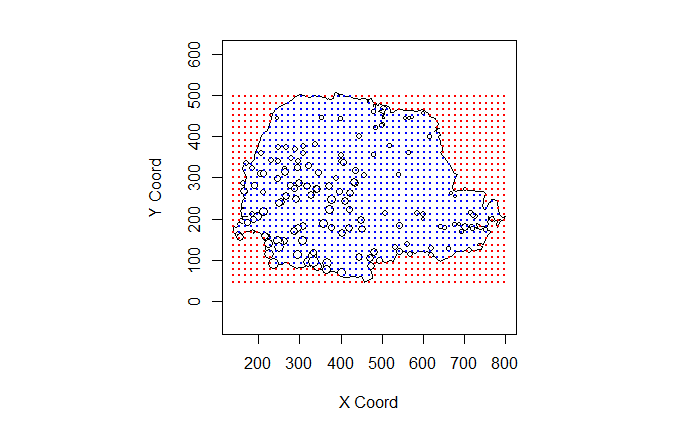

```r
parana.gr0 <- locations.inside(parana.gr, parana$borders)
points(parana.gr0, pch = 19, col = 4, cex = 0.25)
```

```r
class(parana.gr); class(parana.gr0)
```

```
[1] "data.frame"
[1] "data.frame"
```

More generally, simulations can be used to derive maps of quantities of interest. The top panels in next example calls extract minimum and maximum simulated values at each location. The bottom panels shows probabilities of exceeding 300 at each location, and predictive distribution of the proportion of the area exceeding 300.

```r
summary(parana.kc)
```

```
                          Length Class      Mode
predict                      866 -none-     numeric
krige.var                    866 -none-     numeric
beta.est                       3 -none-     numeric
distribution                   1 -none-     character
simulations               866000 -none-     numeric
mean.simulations             866 -none-     numeric
variance.simulations         866 -none-     numeric
quantiles.simulations          5 data.frame list
probabilities.simulations    866 -none-     numeric
sim.means                   1000 -none-     numeric
.Random.seed                 626 -none-     numeric
message                        1 -none-     character
call                           5 -none-     call
```

We now pick four particular locations for prediction.

```r
par(mfrow = c(2, 2), mar = c(2, 3, 1.5, 0.5))
image(parana.kc, col = terrain.colors(21), x.leg = c(500, 750), y.leg = c(0, 50), main = "prediction means")
image(parana.kc, val = parana.kc$quantile[, 3], col = terrain.colors(21), x.leg = c(500, 750),
    y.leg = c(0, 50), main = "prediction medians")
```

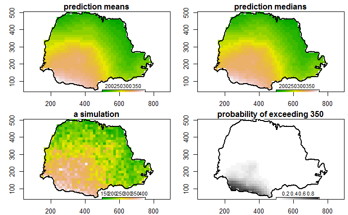

```r
image(parana.kc, val = parana.kc$simulation[, 1], col = terrain.colors(21), x.leg = c(500,
    750), y.leg = c(0, 50), main ="a simulation")
image(parana.kc, val = 1 - parana.kc$prob, col = gray(seq(1, 0.2, length = 21)), x.leg = c(500, 750), y.leg = c(0,
    50), main = "probability of exceeding 350")
```

```r
par(mfrow = c(2, 2), mar = c(2, 3, 2, 0.5))
image(parana.kc, val = apply(parana.kc$simulation, 1, min), col = terrain.colors(21), x.leg = c(500,
    750), y.leg = c(0, 50), main = "simulation minimum")
image(parana.kc, val = apply(parana.kc$simulation, 1, max), col = terrain.colors(21), x.leg = c(500,
    750), y.leg = c(0, 50), main = "simulation maximum")
```

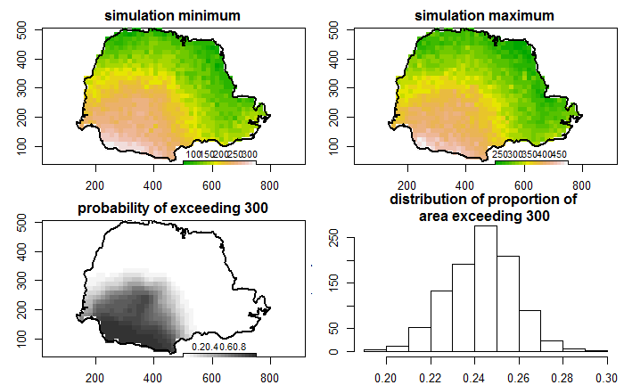

```r
image(parana.kc, val = apply(parana.kc$simulation, 1, function(x) {mean(x > 300, na.rm = T)}),
      x.leg = c(500, 750), y.leg = c(0, 50), col = gray(seq(1, 0.2, length = 21)),
      main = "probability of exceeding 300")
hist(apply(parana.kc$simulation, 2, function(x) {
    mean(x > 300, na.rm = T)
}), xlab = "Precip over 300", main = "distribution of proportion of \narea exceeding 300")
```

```r
loc4 <- cbind(c(300, 480, 680, 244), c(460, 260, 170, 270))
parana.kc4 <- krige.conv(parana, loc = loc4, krige = KC, output = OC)
```

```
krige.conv: results will be returned only for prediction locations inside the borders
krige.conv: model with mean given by a 1st order polynomial on the coordinates
krige.conv: sampling from the predictive distribution (conditional simulations)
krige.conv: Kriging performed using global neighbourhood
```

```r
points(parana)
points(loc4, col = 2, pch = 19)
```

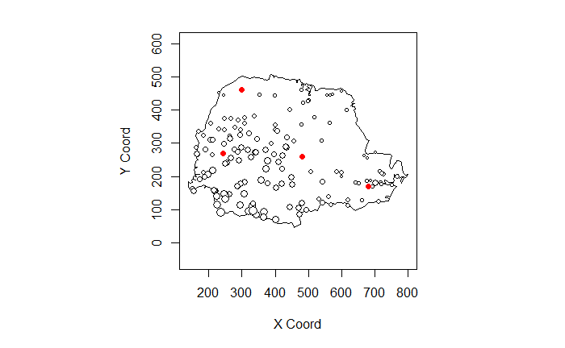

```r
par(mfrow = c(1, 4), mar = c(3.5, 3.5, 0.5, 0.5))
```

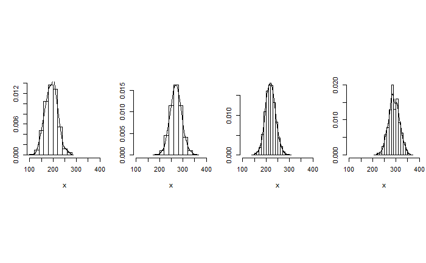

```r
apply(parana.kc4$simulation, 1, function(x) {
    hist(x, prob = T, xlim = c(100, 400), ylab = "", main = "")
    lines(density(x))
})
```

### Question 2

Compare the variability between Bayesian and conventional kriging of the Paraná data set.